# Importancia de los sistemas de referencia de coordenadas en ecología

## 5.4 Las reproyecciones de rasters implican remuestreo

Un ráster es una cuadrícula con una extensión, un tamaño de celda, una posición y un SRC definidos. Al reproyectarlo, la cuadrícula original puede deformarse respecto al nuevo SRC, por lo que es necesario construir una nueva cuadrícula y asignar un valor a cada una de sus celdas a partir de los datos originales. Este proceso se llama remuestreo y puede realizarse mediante distintos métodos. Según el método que utilicemos, los valores de las nuevas celdas pueden variar repecto a los originales.

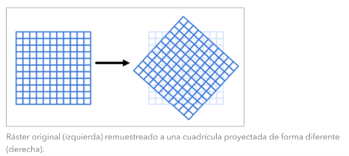

Fuente: [ESRI](https://learn.arcgis.com/es/projects/explore-imagery-spatial-resolution/)

En la siguiente imagen vemos los distintos métodos de remuestreo para calcular los valores de los píxeles de un ráster en la nueva cuadrícula tras la reproyección. El punto rojo representa el centro de la nueva celda, y los puntos azules, las celdas originales utilizadas para calcular su valor, según el método utilizado:

1. **Vecino más próximo:** copia el valor de la celda original cuyo centro está más cerca.
2. **Interpolación bilineal:** combina los valores vecinos mediante una media ponderada según la posición.
3. **Interpolación cúbica:** utiliza el valor de una ventana de pixeles (normalmente de los 8 o 16 píxeles más cercános) para calcular el nuevo valor.

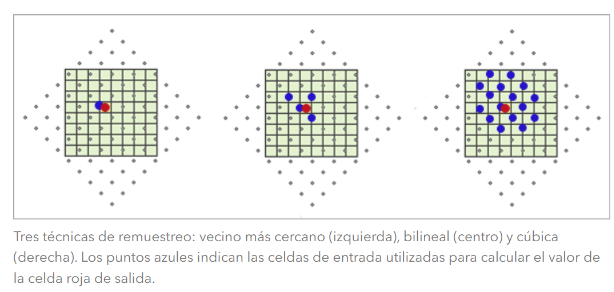

Fuente: [ESRI](https://learn.arcgis.com/es/projects/explore-imagery-spatial-resolution/)

Vamos a entender mejor las implicaciones del remuestreo con el siguiente ejemplo:

### 5.4.1 *Variables continuas:*

Creamos un ráster simulado de temperaturas en EPSG:4326.

```r
r_temperatura <- rast(
  xmin = -3.45, xmax = -3.05,
  ymin = 40.40, ymax = 40.58,
  resolution = 0.002,
  crs = "EPSG:4326"
)

xy <- crds(r_temperatura)

# Asignar gradiente espacial simulado
values(r_temperatura) <- 18 +
  5 * (xy[, 1] - min(xy[, 1])) / diff(range(xy[, 1])) -
  3 * (xy[, 2] - min(xy[, 2])) / diff(range(xy[, 2]))

names(r_temperatura) <- "temperatura"
```

Por defecto, para variables continuas, terra utiliza interpolación bilineal.

```r
# Reproyectar con interpolación bilineal
r_temperatura_utm <- r_temperatura |>
  project("EPSG:25830") #, method = "bilinear")
```

```r
# Comparar geometría, extensión y resolución.

res(r_temperatura)
```

```
[1] 0.002 0.002
```

```r
res(r_temperatura_utm)
```

```
[1] 179.415 179.415
```

```r
ext(r_temperatura)
```

```
SpatExtent : -3.45, -3.05, 40.4, 40.58 (xmin, xmax, ymin, ymax)
```

```r
ext(r_temperatura_utm)
```

```
SpatExtent : 461813.141053749, 495722.579988275, 4472137.58890033, 4492232.0712319 (xmin, xmax, ymin, ymax)
```

```r
ncell(r_temperatura)
```

```
[1] 18000
```

```r
ncell(r_temperatura_utm)
```

```
[1] 21168
```

```r
minmax(r_temperatura)
```

```
    temperatura
min          15
max          23
```

```r
minmax(r_temperatura_utm)
```

```
    temperatura
min    15.01235
max    22.99347
```

Al reproyectar el ráster, los centros de los nuevos píxeles no coinciden con los originales. Como hemos remuestreado con el método de interpolación bilineal, que calcula las temperaturas combinando los valores de los píxeles vecinos en de la cuadrícula original. Por tanto, el ráster reproyectado tiene valores ligeramente distintos a los originales.

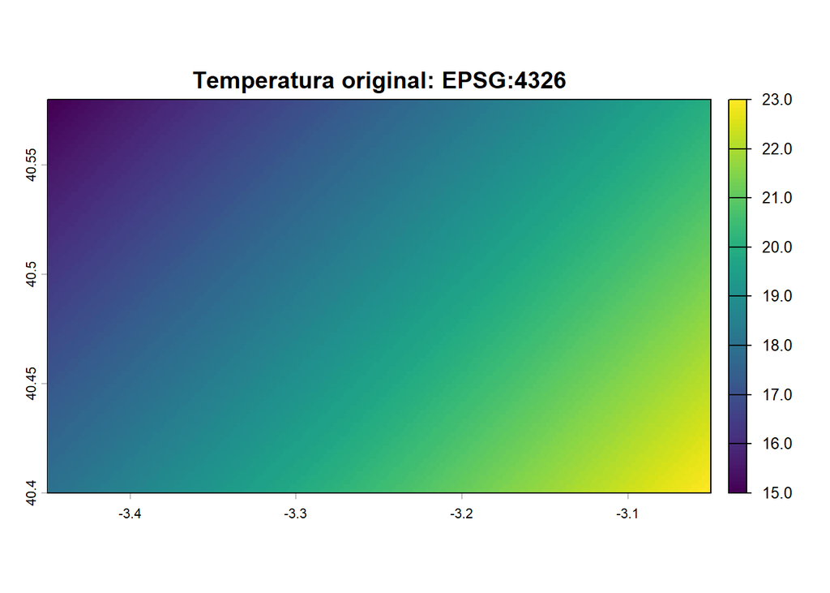

```r
# Visualizar ráster original y reproyectado
plot(r_temperatura, main = "Temperatura original: EPSG:4326",
     colNA = "red"
)
```

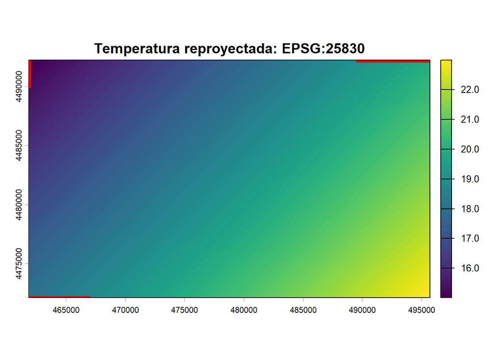

```r
plot(r_temperatura_utm,
     main = "Temperatura reproyectada: EPSG:25830",
     colNA = "red")
```

Vemos que incluso se incorporan píxeles con valores NA. Esto se debe a que el nuevo raster, que se ha desplazado o girado, ha incorporado nuevos píxeles en los bordes, para los que no había valores de origen.